# Pharmaceuticals analysis

For this analysis, 250 mice were treated through a variety of drug regimes over the course of 45 days. Their physiological responses were then monitored over the course of that time. Your objective is to analyze the data to show how the treatments compare according to to the following:

- The most important drugs are Capomulin, Infubinol, Ketapril, and Placebo
- to show how the tumor volume changes over time for each treatment.
- to show how the number of metastatic (cancer spreading) sites changes over time for each treatment.
- to show the number of mice still alive through the course of treatment (Survival Rate)
- to compare the total % tumor volume change for each of the most important drugs across the full 45 days.

# Main observations

Scatter plot and error bars were used to visualize the tumor volume changes over time, after analyzing the plot the following was concluded:

- From the main drugs, only Capomulin reduced the tumor volume.
- From the 10 drugs, only Capomulin and Ramicane reduced the tumor volume.
- The tumor volume variability increased along the time for all drugs.

Scatter plot and error bars also were used to visualize the number of metastatic sites changes over time, after analyzing the plot the following was concluded:

```python
# Dependencies and Setup
%matplotlib inline
import matplotlib.pyplot as plt
import pandas as pd
import numpy as np
from scipy.stats import sem
from copy import copy

# Hide warning messages in notebook
import warnings
warnings.filterwarnings('ignore')

# File to Load
mouse_drug = pd.read_csv("data/mouse_drug_data.csv")
clinical_trial = pd.read_csv("data/clinicaltrial_data.csv")

# Combine the datasets into a single dataset
dataset = pd.merge(mouse_drug, clinical_trial, on="Mouse ID", how="outer")
```

```python
dataset
```

|  | Mouse ID | Drug | Timepoint | Tumor Volume (mm3) | Metastatic Sites |
| --- | --- | --- | --- | --- | --- |
| 0 | f234 | Stelasyn | 0 | 45.000000 | 0 |
| 1 | f234 | Stelasyn | 5 | 47.313491 | 0 |
| 2 | f234 | Stelasyn | 10 | 47.904324 | 0 |
| 3 | f234 | Stelasyn | 15 | 48.735197 | 1 |
| 4 | f234 | Stelasyn | 20 | 51.112713 | 2 |
| ... | ... | ... | ... | ... | ... |
| 1901 | j235 | Placebo | 0 | 45.000000 | 0 |
| 1902 | j235 | Placebo | 5 | 46.588820 | 0 |
| 1903 | j235 | Placebo | 10 | 48.018788 | 1 |
| 1904 | j235 | Placebo | 15 | 51.161138 | 1 |
| 1905 | j235 | Placebo | 20 | 52.942902 | 1 |

1906 rows × 5 columns

## Tumor Response to Treatment

```python
# Store the Mean Tumor Volume Data Grouped by Drug and Timepoint

dataset.groupby(["Drug", "Timepoint"]).mean('Tumor Volume (mm3)')
```

| Drug | Timepoint | Tumor Volume (mm3) | Metastatic Sites |
| --- | --- | --- | --- |
| Capomulin | 0 | 45.000000 | 0.000000 |
|  | 5 | 44.266086 | 0.160000 |
|  | 10 | 43.084291 | 0.320000 |
|  | 15 | 42.064317 | 0.375000 |
|  | 20 | 40.716325 | 0.652174 |
| ... | ... | ... | ... |
| Zoniferol | 25 | 55.432935 | 1.687500 |
|  | 30 | 57.713531 | 1.933333 |
|  | 35 | 60.089372 | 2.285714 |
|  | 40 | 62.916692 | 2.785714 |
|  | 45 | 65.960888 | 3.071429 |

100 rows × 2 columns

```python
# Store the Standard Error of Tumor Volumes Grouped by Drug and Timepoint
df_std_groupby = pd.DataFrame(dataset.groupby(["Drug", "Timepoint"])['Tumor Volume (mm3)'].sem())
df_std_groupby
```

| Drug | Timepoint | Tumor Volume (mm3) |
| --- | --- | --- |
| Capomulin | 0 | 0.000000 |
|  | 5 | 0.448593 |
|  | 10 | 0.702684 |
|  | 15 | 0.838617 |
|  | 20 | 0.909731 |
| ... | ... | ... |
| Zoniferol | 25 | 0.602513 |
|  | 30 | 0.800043 |
|  | 35 | 0.881426 |
|  | 40 | 0.998515 |
|  | 45 | 1.003576 |

100 rows × 1 columns

```python
# Create a dataframe which contains a column for each drug storing the estandar error of "Tumor Volume"
from scipy.stats import sem

dataset.pivot_table(index='Timepoint', columns='Drug', values = 'Tumor Volume (mm3)', aggfunc=[sem], fill_value=0)
```

| Drug Timepoint | sem Capomulin | sem Ceftamin | sem Infubinol | sem Ketapril | sem Naftisol | sem Placebo | sem Propriva | sem Ramicane | sem Stelasyn | sem Zoniferol |
| --- | --- | --- | --- | --- | --- | --- | --- | --- | --- | --- |
| 0 | 0.000000 | 0.000000 | 0.000000 | 0.000000 | 0.000000 | 0.000000 | 0.000000 | 0.000000 | 0.000000 | 0.000000 |
| 5 | 0.448593 | 0.164505 | 0.235102 | 0.264819 | 0.202385 | 0.218091 | 0.231708 | 0.482955 | 0.239862 | 0.188950 |
| 10 | 0.702684 | 0.236144 | 0.282346 | 0.357421 | 0.319415 | 0.402064 | 0.376195 | 0.720225 | 0.433678 | 0.263949 |
| 15 | 0.838617 | 0.332053 | 0.357705 | 0.580268 | 0.444378 | 0.614461 | 0.466109 | 0.770432 | 0.493261 | 0.370544 |
| 20 | 0.909731 | 0.359482 | 0.476210 | 0.726484 | 0.595260 | 0.839609 | 0.555181 | 0.786199 | 0.621889 | 0.533182 |
| 25 | 0.881642 | 0.439356 | 0.550315 | 0.755413 | 0.813706 | 1.034872 | 0.577401 | 0.746991 | 0.741922 | 0.602513 |
| 30 | 0.934460 | 0.490620 | 0.631061 | 0.934121 | 0.975496 | 1.218231 | 0.746045 | 0.864906 | 0.899548 | 0.800043 |
| 35 | 1.052241 | 0.692248 | 0.984155 | 1.127867 | 1.013769 | 1.287481 | 1.084929 | 0.967433 | 1.003186 | 0.881426 |
| 40 | 1.223608 | 0.708505 | 1.055220 | 1.158449 | 1.118567 | 1.370634 | 1.564779 | 1.128445 | 1.410435 | 0.998515 |
| 45 | 1.223977 | 0.902358 | 1.144427 | 1.453186 | 1.416363 | 1.351726 | 1.888586 | 1.226805 | 1.576556 | 1.003576 |

```python
# Create a dataframe wich contains a column for each drug storing the value of "Tumor Volume"

dataset.pivot_table(index='Timepoint', columns='Drug', values = 'Tumor Volume (mm3)', fill_value=0)
```

| Drug Timepoint | Capomulin | Ceftamin | Infubinol | Ketapril | Naftisol | Placebo | Propriva | Ramicane | Stelasyn | Zoniferol |
| --- | --- | --- | --- | --- | --- | --- | --- | --- | --- | --- |
| 0 | 45.000000 | 45.000000 | 45.000000 | 45.000000 | 45.000000 | 45.000000 | 45.000000 | 45.000000 | 45.000000 | 45.000000 |
| 5 | 44.266086 | 46.503051 | 47.062001 | 47.389175 | 46.796098 | 47.125589 | 47.248967 | 43.944859 | 47.527452 | 46.851818 |
| 10 | 43.084291 | 48.285125 | 49.403909 | 49.582269 | 48.694210 | 49.423329 | 49.101541 | 42.531957 | 49.463844 | 48.689881 |
| 15 | 42.064317 | 50.094055 | 51.296397 | 52.399974 | 50.933018 | 51.359742 | 51.067318 | 41.495061 | 51.529409 | 50.779059 |
| 20 | 40.716325 | 52.157049 | 53.197691 | 54.920935 | 53.644087 | 54.364417 | 53.346737 | 40.238325 | 54.067395 | 53.170334 |
| 25 | 39.939528 | 54.287674 | 55.715252 | 57.678982 | 56.731968 | 57.482574 | 55.504138 | 38.974300 | 56.166123 | 55.432935 |
| 30 | 38.769339 | 56.769517 | 58.299397 | 60.994507 | 59.559509 | 59.809063 | 58.196374 | 38.703137 | 59.826738 | 57.713531 |
| 35 | 37.816839 | 58.827548 | 60.742461 | 63.371686 | 62.685087 | 62.420615 | 60.350199 | 37.451996 | 62.440699 | 60.089372 |
| 40 | 36.958001 | 61.467895 | 63.162824 | 66.068580 | 65.600754 | 65.052675 | 63.045537 | 36.574081 | 65.356386 | 62.916692 |
| 45 | 36.236114 | 64.132421 | 65.755562 | 70.662958 | 69.265506 | 68.084082 | 66.258529 | 34.955595 | 68.438310 | 65.960888 |

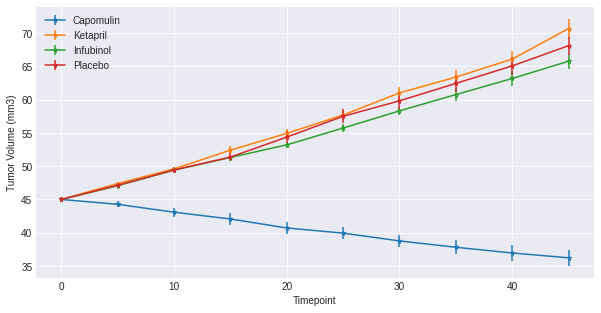

```python
#Depict the tumor volume over time for the main four treatments and its standard error

df_error = dataset.pivot_table(index='Timepoint', columns='Drug', values = 'Tumor Volume (mm3)', aggfunc=[sem], fill_value=0)
df_plot = dataset.pivot_table(index='Timepoint', columns='Drug', values = 'Tumor Volume (mm3)', fill_value=0)
df_plot = df_plot[['Capomulin', 'Ketapril','Infubinol','Placebo']]

plt.style.use('seaborn-darkgrid')
plt.rcParams['figure.figsize'] = [10, 5]
fig, ax = plt.subplots()

for column in df_plot:
    ax.errorbar(
        df_plot.index,
        df_plot[column],
        ls="-", marker="*", markersize=5, markerfacecolor="None",
        yerr = df_error[('sem', column)],
        label=column
)

plt.legend()
plt.xlabel("Timepoint")
plt.ylabel("Tumor Volume (mm3)")
plt.show()
```

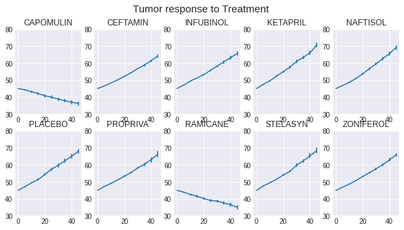

```python
#Depict the tumor volume over time by treatment type and its standard error

df_error = dataset.pivot_table(index='Timepoint', columns='Drug', values = 'Tumor Volume (mm3)', aggfunc=[sem], fill_value=0)
df_plot = dataset.pivot_table(index='Timepoint', columns='Drug', values = 'Tumor Volume (mm3)', fill_value=0)

plt.style.use('seaborn-darkgrid')
plt.rcParams['figure.figsize'] = [10, 5]
fig, ax = plt.subplots(2,5)
plt.suptitle("Tumor response to Treatment", fontsize=15, y=0.98)
for column, ax in zip(df_plot.columns, ax.ravel()):
    index = df_plot.loc[:, column].index
    df_plot.loc[:, str(column)].plot(kind = "line", y = index, legend = False, yerr = df_error[('sem', str(column))], ax=ax)
    ax.set_title(column.upper())
    ax.set_xlabel("")
    ax.set_ylim([30, 80])
plt.show()
```

## Metastatic Response to Treatment

```python
# Store the the number of metastatic sites Data Grouped by Drug and Timepoint
pd.DataFrame(dataset.groupby(["Drug", "Timepoint"])['Metastatic Sites'].count())
```

| Drug | Timepoint | Metastatic Sites |
| --- | --- | --- |
| Capomulin | 0 | 25 |
|  | 5 | 25 |
|  | 10 | 25 |
|  | 15 | 24 |
|  | 20 | 23 |
| ... | ... | ... |
| Zoniferol | 25 | 16 |
|  | 30 | 15 |
|  | 35 | 14 |
|  | 40 | 14 |
|  | 45 | 14 |

100 rows × 1 columns

```python
# Store the Standard Error of the number of metastatic sites Grouped by Drug and Timepoint
pd.DataFrame(dataset.groupby(["Drug", "Timepoint"])['Metastatic Sites'].sem())
```

| Drug | Timepoint | Metastatic Sites |
| --- | --- | --- |
| Capomulin | 0 | 0.000000 |
|  | 5 | 0.074833 |
|  | 10 | 0.125433 |
|  | 15 | 0.132048 |
|  | 20 | 0.161621 |
| ... | ... | ... |
| Zoniferol | 25 | 0.236621 |
|  | 30 | 0.248168 |
|  | 35 | 0.285714 |
|  | 40 | 0.299791 |
|  | 45 | 0.286400 |

100 rows × 1 columns

```python
# Create a dataframe wich contains a column for each drug storing the number of "Metastatic Sites"
dataset.pivot_table(index='Timepoint', columns='Drug', values = 'Metastatic Sites', aggfunc=[np.sum], fill_value=0)
```

| Drug Timepoint | sum Capomulin | sum Ceftamin | sum Infubinol | sum Ketapril | sum Naftisol | sum Placebo | sum Propriva | sum Ramicane | sum Stelasyn | sum Zoniferol |
| --- | --- | --- | --- | --- | --- | --- | --- | --- | --- | --- |
| 0 | 0 | 0 | 0 | 0 | 0 | 0 | 0 | 0 | 0 | 0 |
| 5 | 4 | 8 | 7 | 7 | 6 | 9 | 8 | 3 | 6 | 4 |
| 10 | 8 | 12 | 14 | 13 | 11 | 20 | 13 | 6 | 11 | 11 |
| 15 | 9 | 15 | 19 | 16 | 18 | 25 | 13 | 8 | 18 | 17 |
| 20 | 15 | 20 | 21 | 23 | 23 | 29 | 17 | 8 | 20 | 22 |
| 25 | 18 | 27 | 23 | 31 | 27 | 33 | 19 | 15 | 22 | 27 |
| 30 | 24 | 31 | 27 | 37 | 31 | 34 | 21 | 18 | 25 | 29 |
| 35 | 26 | 29 | 20 | 39 | 34 | 37 | 23 | 20 | 25 | 32 |
| 40 | 29 | 33 | 21 | 41 | 37 | 38 | 25 | 22 | 19 | 39 |
| 45 | 31 | 35 | 19 | 37 | 33 | 36 | 18 | 25 | 19 | 43 |

```python
# Create a dataframe wich contains a column for each drug storing the estandar error of "Metastatic Sites"
dataset.pivot_table(index='Timepoint', columns='Drug', values = 'Metastatic Sites', aggfunc=[sem], fill_value=0)
```

| Drug Timepoint | sem Capomulin | sem Ceftamin | sem Infubinol | sem Ketapril | sem Naftisol | sem Placebo | sem Propriva | sem Ramicane | sem Stelasyn | sem Zoniferol |
| --- | --- | --- | --- | --- | --- | --- | --- | --- | --- | --- |
| 0 | 0.000000 | 0.000000 | 0.000000 | 0.000000 | 0.000000 | 0.000000 | 0.000000 | 0.000000 | 0.000000 | 0.000000 |
| 5 | 0.074833 | 0.108588 | 0.091652 | 0.098100 | 0.093618 | 0.100947 | 0.095219 | 0.066332 | 0.087178 | 0.077709 |
| 10 | 0.125433 | 0.152177 | 0.159364 | 0.142018 | 0.163577 | 0.115261 | 0.105690 | 0.090289 | 0.123672 | 0.109109 |
| 15 | 0.132048 | 0.180625 | 0.194015 | 0.191381 | 0.158651 | 0.190221 | 0.136377 | 0.115261 | 0.153439 | 0.111677 |
| 20 | 0.161621 | 0.241034 | 0.234801 | 0.236680 | 0.181731 | 0.234064 | 0.171499 | 0.119430 | 0.200905 | 0.166378 |
| 25 | 0.181818 | 0.258831 | 0.265753 | 0.288275 | 0.185240 | 0.263888 | 0.199095 | 0.119430 | 0.219824 | 0.236621 |
| 30 | 0.172944 | 0.249479 | 0.227823 | 0.347467 | 0.266667 | 0.300264 | 0.266469 | 0.139968 | 0.230641 | 0.248168 |
| 35 | 0.169496 | 0.266526 | 0.224733 | 0.361418 | 0.330464 | 0.341412 | 0.366667 | 0.145997 | 0.240983 | 0.285714 |
| 40 | 0.175610 | 0.289128 | 0.314466 | 0.315725 | 0.321702 | 0.297294 | 0.433903 | 0.160591 | 0.312815 | 0.299791 |
| 45 | 0.202591 | 0.286101 | 0.309320 | 0.278722 | 0.351104 | 0.304240 | 0.428571 | 0.190221 | 0.359062 | 0.286400 |

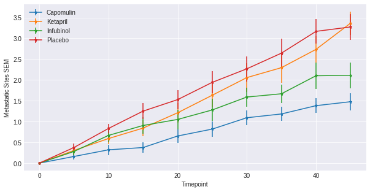

```python
#Depict the number of metastatic sites over time for the main four treatments and its standard error

df_error = dataset.pivot_table(index='Timepoint', columns='Drug', values = 'Metastatic Sites', aggfunc=[sem], fill_value=0)
df_plot = dataset.pivot_table(index='Timepoint', columns='Drug', values = 'Metastatic Sites', fill_value=0)
df_plot = df_plot[['Capomulin', 'Ketapril','Infubinol','Placebo']]

plt.style.use('seaborn-darkgrid')
plt.rcParams['figure.figsize'] = [10, 5]
fig, ax = plt.subplots()

for column in df_plot:
    ax.errorbar(
        df_plot.index,
        df_plot[column],
        ls="-", marker="*", markersize=5, markerfacecolor="None",
        yerr = df_error[('sem', column)],
        label=column
)

plt.legend()
plt.xlabel("Timepoint")
plt.ylabel("Metastatic Sites SEM")
plt.show()
```

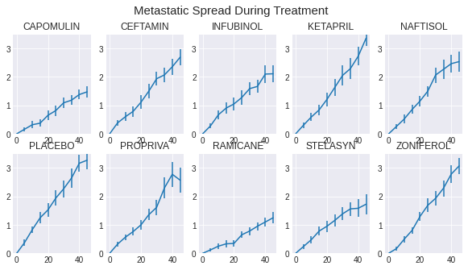

```python
#Depict the number of metastatic sites over time by treatment type and its standard error

df_error = dataset.pivot_table(index='Timepoint', columns='Drug', values = 'Metastatic Sites', aggfunc=[sem], fill_value=0)
df_plot = dataset.pivot_table(index='Timepoint', columns='Drug', values = 'Metastatic Sites', fill_value=0)

plt.style.use('seaborn-darkgrid')
plt.rcParams['figure.figsize'] = [10, 5]
fig, ax = plt.subplots(2,5)
plt.suptitle("Metastatic Spread During Treatment", fontsize=15, y=0.98)
for column, ax in zip(df_plot.columns, ax.ravel()):
    index = df_plot.loc[:, column].index
    df_plot.loc[:, str(column)].plot(kind = "line", y = index, legend = False, yerr = df_error[('sem', str(column))], ax=ax)
    ax.set_title(column.upper())
    ax.set_xlabel("")
    ax.set_ylim([0, 3.5])
plt.show()
```

## Survival Rates

```python
# Store the number of mice Data Grouped by Drug and Timepoint
pd.DataFrame(dataset.groupby(["Drug", "Timepoint"])['Metastatic Sites'].count())
```

[output not shown]

```python
# Create a dataframe wich contains a column for each drug storing the number of mice
dataset.pivot_table(index='Timepoint', columns='Drug', values = 'Mouse ID', aggfunc=[len], fill_value=0)
```

| Drug Timepoint | len Capomulin | len Ceftamin | len Infubinol | len Ketapril | len Naftisol | len Placebo | len Propriva | len Ramicane | len Stelasyn | len Zoniferol |
| --- | --- | --- | --- | --- | --- | --- | --- | --- | --- | --- |
| 0 | 25 | 25 | 25 | 25 | 25 | 25 | 26 | 25 | 26 | 25 |
| 5 | 25 | 21 | 25 | 23 | 23 | 24 | 25 | 25 | 25 | 24 |
| 10 | 25 | 20 | 21 | 22 | 21 | 24 | 23 | 24 | 23 | 22 |
| 15 | 24 | 19 | 21 | 19 | 21 | 20 | 17 | 24 | 23 | 21 |
| 20 | 23 | 18 | 20 | 19 | 20 | 19 | 17 | 23 | 21 | 17 |
| 25 | 22 | 18 | 18 | 19 | 18 | 17 | 14 | 23 | 19 | 16 |
| 30 | 22 | 16 | 17 | 18 | 15 | 15 | 13 | 23 | 18 | 15 |
| 35 | 22 | 14 | 12 | 17 | 15 | 14 | 10 | 21 | 16 | 14 |
| 40 | 21 | 14 | 10 | 15 | 15 | 12 | 9 | 20 | 12 | 14 |
| 45 | 21 | 13 | 9 | 11 | 13 | 11 | 7 | 20 | 11 | 14 |

```python
# Calculate a new dataframe which stores the survival rate of the mice per treatmen by timepoint

df = dataset.pivot_table(index='Timepoint', columns='Drug', values = 'Mouse ID', aggfunc=[len], fill_value=0)
df.len/df.len.max()*100
```

| Drug Timepoint | Capomulin | Ceftamin | Infubinol | Ketapril | Naftisol | Placebo | Propriva | Ramicane | Stelasyn | Zoniferol |
| --- | --- | --- | --- | --- | --- | --- | --- | --- | --- | --- |
| 0 | 100.0 | 100.0 | 100.0 | 100.0 | 100.0 | 100.0 | 100.000000 | 100.0 | 100.000000 | 100.0 |
| 5 | 100.0 | 84.0 | 100.0 | 92.0 | 92.0 | 96.0 | 96.153846 | 100.0 | 96.153846 | 96.0 |
| 10 | 100.0 | 80.0 | 84.0 | 88.0 | 84.0 | 96.0 | 88.461538 | 96.0 | 88.461538 | 88.0 |
| 15 | 96.0 | 76.0 | 84.0 | 76.0 | 84.0 | 80.0 | 65.384615 | 96.0 | 88.461538 | 84.0 |
| 20 | 92.0 | 72.0 | 80.0 | 76.0 | 80.0 | 76.0 | 65.384615 | 92.0 | 80.769231 | 68.0 |
| 25 | 88.0 | 72.0 | 72.0 | 76.0 | 72.0 | 68.0 | 53.846154 | 92.0 | 73.076923 | 64.0 |
| 30 | 88.0 | 64.0 | 68.0 | 72.0 | 60.0 | 60.0 | 50.000000 | 92.0 | 69.230769 | 60.0 |
| 35 | 88.0 | 56.0 | 48.0 | 68.0 | 60.0 | 56.0 | 38.461538 | 84.0 | 61.538462 | 56.0 |
| 40 | 84.0 | 56.0 | 40.0 | 60.0 | 60.0 | 48.0 | 34.615385 | 80.0 | 46.153846 | 56.0 |
| 45 | 84.0 | 52.0 | 36.0 | 44.0 | 52.0 | 44.0 | 26.923077 | 80.0 | 42.307692 | 56.0 |

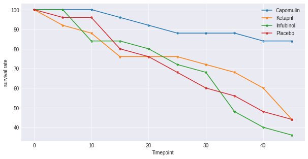

```python
#Depict the survival rate over time for the most important treatments

df_plot = dataset.pivot_table(index='Timepoint', columns='Drug', values = 'Mouse ID', aggfunc=[len], fill_value=0)
df_plot = df_plot.len/df_plot.len.max()*100

df_plot = df_plot[['Capomulin', 'Ketapril','Infubinol','Placebo']]

plt.style.use('seaborn-darkgrid')
plt.rcParams['figure.figsize'] = [10, 5]
fig, ax = plt.subplots()

for column in df_plot:
    ax.errorbar(
        df_plot.index,
        df_plot[column],
        ls="-", marker="*", markersize=5, markerfacecolor="None",
        label=column
)

plt.legend()
plt.xlabel("Timepoint")
plt.ylabel("survival rate")
plt.show()
```

## Summary Bar Graph

```python
# Calculate the volume change in percent for the main treatments

df = dataset.pivot_table(index='Timepoint', columns='Drug', values = 'Tumor Volume (mm3)', fill_value=0)
df = pd.concat([df.iloc[0, :],df.iloc[-1, :].rename('change (%)')],axis=1)
df = df.pct_change(axis=1)*100
df
```

| Drug | 0 | change (%) |
| --- | --- | --- |
| Capomulin | NaN | -19.475303 |
| Ceftamin | NaN | 42.516492 |
| Infubinol | NaN | 46.123472 |
| Ketapril | NaN | 57.028795 |
| Naftisol | NaN | 53.923347 |
| Placebo | NaN | 51.297960 |
| Propriva | NaN | 47.241175 |
| Ramicane | NaN | -22.320900 |
| Stelasyn | NaN | 52.085134 |
| Zoniferol | NaN | 46.579751 |

[output not shown]

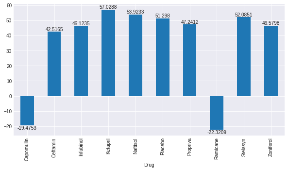

```python
#Depict the percentage of change in tumor volume for the most important treatments
ax = df.iloc[:,1].plot(kind='bar')
ax.bar_label(ax.containers[0])
```